# Seattle Crime Data - Part 2

Amruta Jadhav

##### Setup

```r
# Load standard libraries
library(tidyverse)
library(gridExtra)
```

#### 1. 50 States in the USA

In this problem we will use the `state` dataset, available as part of the R statistical computing platform. This data is related to the 50 states of the United States of America. Load the data and use it to answer the following questions.

```r
# Loading the state data by using tibble

state_data <-
  tibble(State = state.name,
         Region = state.region,
         Abb = state.abb,
         Division = state.division) %>%
  bind_cols(as_tibble(state.x77))
```

##### (a) Describe the data and each variable it contains. Tidy the data, preparing it for a data analysis.

##### **Solution:**

The data has 50 rows for 50 US states & 12 columns.

state.abb: character vector of 2-letter abbreviations for the state names.

state.area: numeric vector of state areas (in square miles).

state.center: list with components named x and y giving the approximate geographic center of each state in negative longitude and latitude. Alaska and Hawaii are placed just off the West Coast.

state.division: factor giving state divisions (New England, Middle Atlantic, South Atlantic, East South Central, West South Central, East North Central, West North Central, Mountain, and Pacific).

state.name: character vector giving the full state names.

state.region: factor giving the region (Northeast, South, North Central, West) that each state belongs to.

Population: population estimate as of July 1, 1975

Income: per capita income (1974)

Illiteracy: illiteracy (1970, percent of population)

Life Exp: life expectancy in years (1969–71)

Murder: murder and non-negligent manslaughter rate per 100,000 population (1976)

HS Grad: percent high-school graduates (1970)

Frost: mean number of days with minimum temperature below freezing (1931–1960) in capital or large city

Area: land area in square miles

References: US state Facts & Figure - R documentation retrieved from https://stat.ethz.ch/R-manual/R-devel/library/datasets/html/state.html

```r
#Describing the data & variables in the data

glimpse(state_data)
```

```
## Rows: 50
## Columns: 12
## $ State      <chr> "Alabama", "Alaska", "Arizona", "Arkansas", "California"...
## $ Region     <fct> South, West, West, South, West, West, Northeast, South, ...
## $ Abb        <chr> "AL", "AK", "AZ", "AR", "CA", "CO", "CT", "DE", "FL", "G...
## $ Division   <fct> East South Central, Pacific, Mountain, West South Centra...
## $ Population <dbl> 3615, 365, 2212, 2110, 21198, 2541, 3100, 579, 8277, 493...
## $ Income     <dbl> 3624, 6315, 4530, 3378, 5114, 4884, 5348, 4809, 4815, 40...
## $ Illiteracy <dbl> 2.1, 1.5, 1.8, 1.9, 1.1, 0.7, 1.1, 0.9, 1.3, 2.0, 1.9, 0...
## $ `Life Exp` <dbl> 69.05, 69.31, 70.55, 70.66, 71.71, 72.06, 72.48, 70.06, ...
## $ Murder     <dbl> 15.1, 11.3, 7.8, 10.1, 10.3, 6.8, 3.1, 6.2, 10.7, 13.9, ...
## $ `HS Grad`  <dbl> 41.3, 66.7, 58.1, 39.9, 62.6, 63.9, 56.0, 54.6, 52.6, 40...
## $ Frost      <dbl> 20, 152, 15, 65, 20, 166, 139, 103, 11, 60, 0, 126, 127,...
## $ Area       <dbl> 50708, 566432, 113417, 51945, 156361, 103766, 4862, 1982...
```

```r
colnames(state_data)
```

```
##  [1] "State"      "Region"     "Abb"        "Division"   "Population"
##  [6] "Income"     "Illiteracy" "Life Exp"   "Murder"     "HS Grad"
## [11] "Frost"      "Area"
```

```r
# Changing column name

colnames(state_data)[colnames(state_data) == 'HS Grad'] <- 'HSGrad'
colnames(state_data)[colnames(state_data) == 'Life Exp'] <- 'LifeExp'
```

##### (b) Suppose you want to explore the relationship between a state’s `Murder` rate and other characteristics of the state, for example population, illiteracy rate, and more. Begin by examining the bivariate relationships present in the data. What does your analysis suggest might be important varibles to consider in building a model to explain variation in murder rates?

##### **Solution:**

I have ploted the bivariate relationships between murder rate and income, illiteracy, High School Graduation rate and population. There was no clear realtion between population and murder rate but:  
1. the murder rate decreased with a rise in income  
2. the murder rate decreased with a rise in graduation rate  
3. the murder rate increased with a rise in illiteracy percentage

So, the income, illiteracy & HS Grad variables can be important in building a model to explain variation in murder cases.

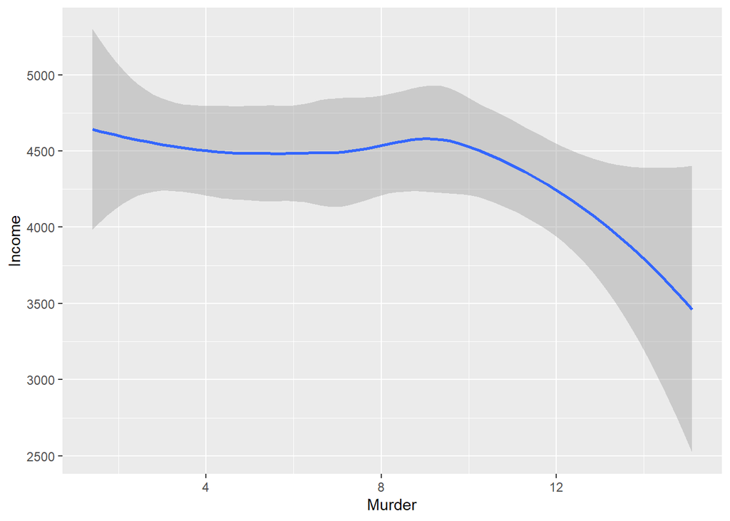

```r
# Finding the relation between murder rate & income

ggplot(state_data, aes(Murder, Income)) + geom_smooth()
```

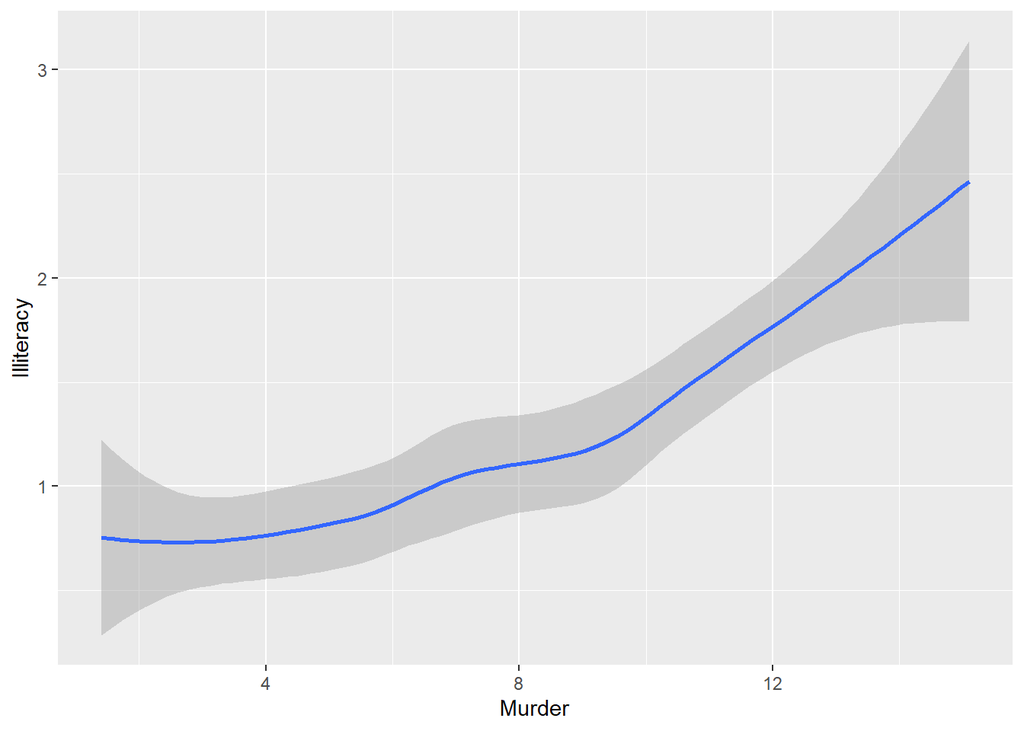

```r
# Finding the relation between murder rate & illiteracy

ggplot(state_data, aes(Murder, Illiteracy)) + geom_smooth()
```

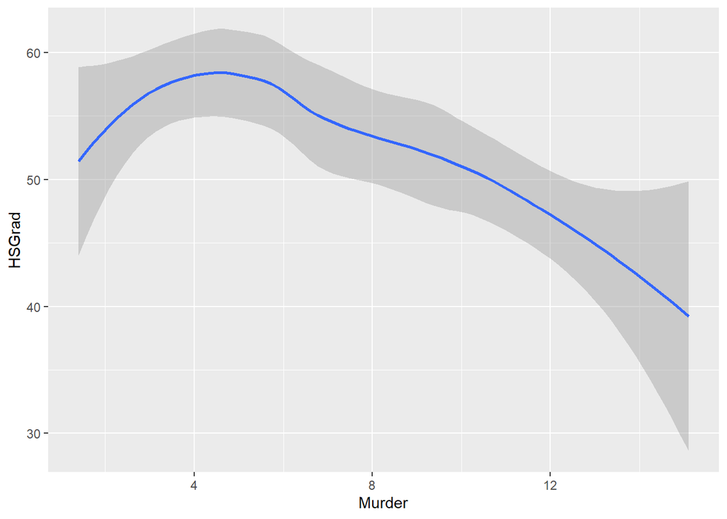

```r
# Finding the relation between murder rate & HS Grad

ggplot(state_data, aes(Murder, HSGrad)) + geom_smooth()
```

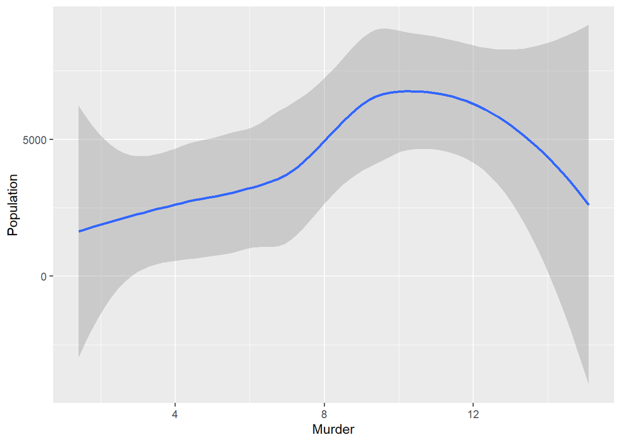

```r
# Finfing the relation between murder rate & population

ggplot(state_data, aes(Murder, Population)) + geom_smooth()
```

##### (c) Develop a new research question of your own that you can address using the `state` dataset. Clearly state the question you are going to address. Provide at least one visualization to support your exploration of this question. Discuss what you find.

##### **Solution:**

The research question I have formulated is:

Is there a relationship between the income and life expectancy? Do people with higher live more?

After plotting the graph, I can say that there is a relation between income & life expectancy. As the income rises, the life expectancy increase.

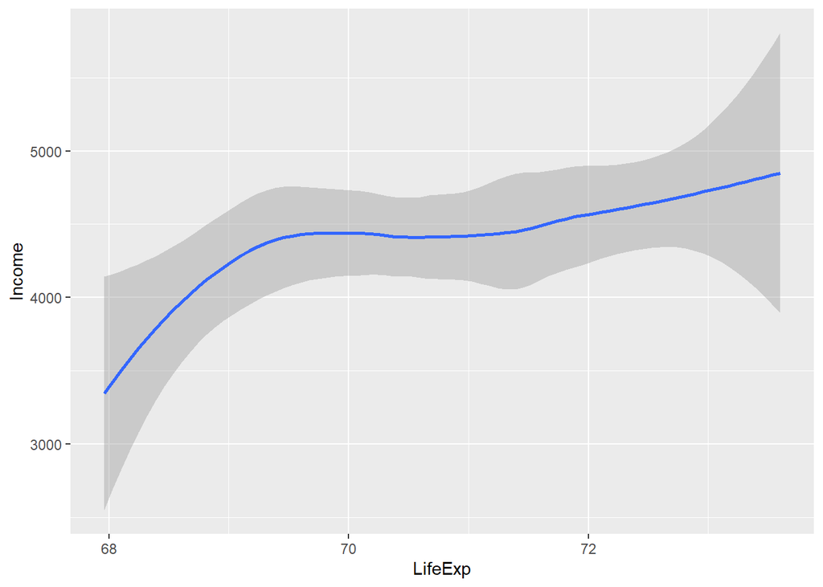

```r
# Finding the relation between income & life expetancy

ggplot(state_data, aes(LifeExp, Income)) + geom_smooth()
```

#### Problem 2: Asking Data Science Questions: Crime and Educational Attainment

In part 1, you joined data about crimes and educational attainment. Here you will use this new combined dataset to examine questions around crimes in Seattle and the educational attainment of people living in the areas in which the crime occurred.

```r
# Importing data

crime_data <- read.csv("C:\\CodeR - DataSci1\\PS-4\\final_dataset.csv")
```

#### (a) Develop a Data Science Question

Develop your own question to address in this analysis. Your question should be specific and measurable, and it should be able to be addressed through a basic analysis of the crime dataset you compiled in Problem Set 3.

##### **Solution:**

The question I wish to address using the Seattle crime data is:

Is there a definite relationship between the crime rate and education attainment in the different regions?

#### (b) Describe and Summarize

Briefly summarize the dataset, describing what data exists and its basic properties. Comment on any issues that need to be resolved before you can proceed with your analysis.

##### **Solution:**

There are 523,591 rows & 45 columns in the data as shown below. Through the glimpse function we can see that variables have datatypes double, character & integer. As I mentioned in PS3 that missing values are 0.6% as that of the dataset, so I will remove these value before performing analysis.

```r
# Summarizing the dataset

glimpse(crime_data)
```

```
## Rows: 523,591
## Columns: 45
## $ Report.Number                          <dbl> 1.975e+12, 1.976e+12, 1.979e...
## $ Occurred.Date                          <chr> "12/16/1975", "01/01/1976", ...
## $ Occurred.Time                          <int> 900, 1, 1600, 2029, 2000, 15...
## $ Reported.Date                          <chr> "12/16/1975", "01/31/1976", ...
## $ Reported.Time                          <int> 1500, 2359, 1430, 2030, 435,...
## $ Crime.Subcategory                      <chr> "BURGLARY-RESIDENTIAL", "SEX...
## $ Primary.Offense.Description            <chr> "BURGLARY-FORCE-RES", "SEXOF...
## $ Precinct                               <chr> "SOUTH", "UNKNOWN", "EAST", ...
## $ Sector                                 <chr> "R", "", "G", "S", "W", "M",...
## $ Beat                                   <chr> "R3", "", "G2", "S2", "W3", ...
## $ Neighborhood                           <chr> "LAKEWOOD/SEWARD PARK", "UNK...
## $ Location.1                             <chr> "(47.5527951110333, -122.268...
## $ Latitude                               <dbl> 47.55280, NA, 47.59590, 47.5...
```

[output cut: 32 more lines]

```r
colnames(crime_data)
```

```
##  [1] "Report.Number"
##  [2] "Occurred.Date"
##  [3] "Occurred.Time"
##  [4] "Reported.Date"
##  [5] "Reported.Time"
##  [6] "Crime.Subcategory"
##  [7] "Primary.Offense.Description"
##  [8] "Precinct"
##  [9] "Sector"
## [10] "Beat"
## [11] "Neighborhood"
## [12] "Location.1"
## [13] "Latitude"
## [14] "Longitude"
## [15] "census_tract"
```

[output cut: 30 more lines]

```r
crime_edu_data <- na.omit(crime_data)
```

#### (c) Data Analysis

Use the dataset to provide empirical evidence that addressed your question from part (a). Discuss your results. Provide at least one visualization to support your narrative.

##### **Solution:**

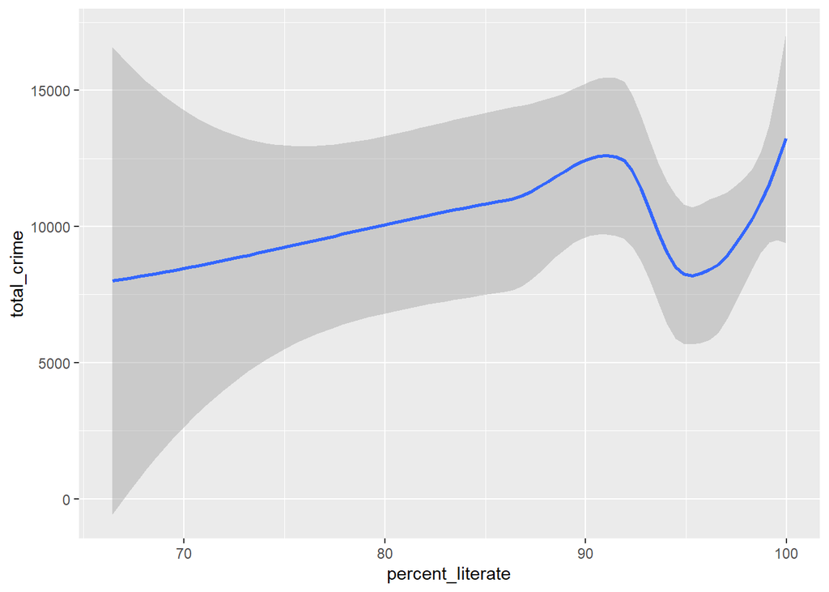

```r
# Finding out the crime count for the census tract regions of Seattle
data1 <- crime_edu_data %>% select(GEO.display.label, Report.Number) %>%
  group_by(GEO.display.label) %>%
  count() %>%
  arrange(desc(n))

colnames(data1)[colnames(data1) == 'n'] <- 'total_crime'

# Finding literacy rate of each neighborhood
# Considering that people that obtained at least a high school diploma as literate

data2 <- crime_edu_data %>% mutate(total_literate = high_school_diploma + ged_or_alternative_credential + some_college_less_than_1_year + some_college_1_or_more_years_no_degree + associates_degree + bachelors_degree + masters_degree + professional_school_degree + doctorate_degree)

# Calculating percentage of literacy

data3 <- data2 %>%  mutate(percent_literate = (total_literate/total) * 100) %>% select(GEO.display.label, percent_literate) %>% unique()

# Joining data1 & data3

data4 <- data1 %>% left_join(data3, by = "GEO.display.label")

ggplot(data4, aes(percent_literate, total_crime)) + geom_smooth()
```

#### (d) Reflect and Question

Comment the questions (and answers) in this analysis. Were you able to answer all of these questions? Are all questions well defined? Is the data good enough to answer all these?

##### **Solution:**

I believe there is a fundamental problem with trying to find a relationship between the crimes data and education data because of following reasons:  
1. Crimes data captures crimes over several decades from around 1975 to around 2018. Whereas education data is a census captured in a single year.  
2. Moreover, it is not stated that which year the education data was captured, like 2000 or 2010. So it is not possible to filter down the crimes data to the particular year to which the education data corresponds.  
3. Therefore I think the given data is not enough to establish a reliable relationship between education and crimes. As a mitigation, we can try to guess the census year by comparing the total population of the city (obtained by adding the the Total column) to external sources of census data and then use that year to filter the crime data.